# Computational Musicology

## Corpus: my personal “This is: Sebas” playlist

In 2017 i created a playlist with the idea of adding every song i like to it through the years. Until now i have added 1095 songs to my playlist. It’s also important to note that my main source of music is spotify. I’ve always found that my music taste is kind of variable with a lot of different genre’s but i do wonder if there are similarities or patterns to be found in all the music to be able to pinpoint why i like certain music.

## Global Playlist Research

# key global playlist/years

Below shows the key frequency over the whole playlist. You can see that i don’t necessarily have a preference of a certain key over the whole playlist or per year. However, i do seem to dislike D#.

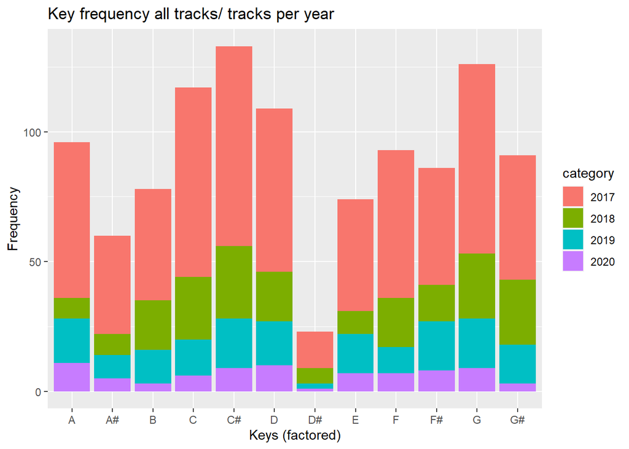

# mode global playlist/years

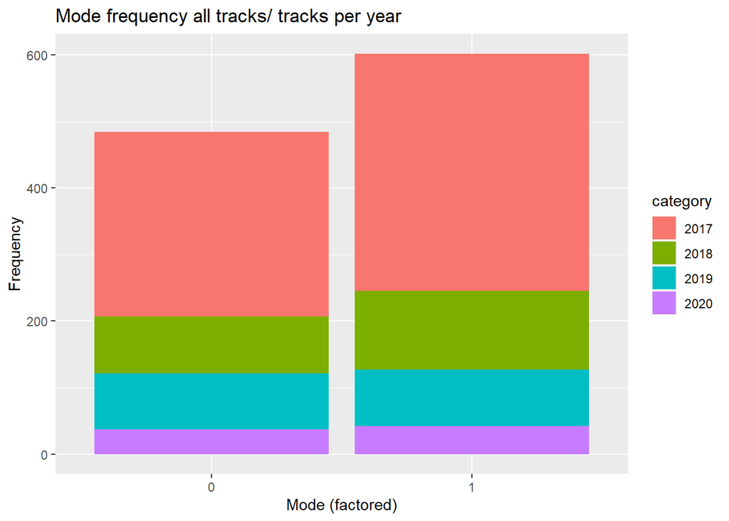

## Further Research

As i was struggling too much with finding what graphs and data to use i don’t have a lot of interesting things yet. I would like to expand on researching per year and over the entire playlist, but also experiment with smaller groups: per month, seasonal. Furthermore i’d like to involve genres as that seems like one of the most important things in music. Sadly i have yet to figure out how to get genre data per track if at all possible.

## Link to playlist

https://open.spotify.com/playlist/5zSzru2LrIR0o8SUyLelyd?si=G_XxooasSYyhyixlqyRA8Q